# Non-stationary Spatial Model for Dengue in Brazil: A Hands-On Guide

Esmail Abdul Fattah

2025-10-08

## 1 1. Motivation and Aim

Spatial disease risk **rarely varies uniformly** across large areas. The standard (stationary) Besag model assumes a **single precision** (i.e., a single smoothness/variance level) everywhere. In contrast, the **non-stationary `fbesag`** model allows the precision to **vary by sub-region**, while still sharing information across boundaries. A **joint penalized-complexity (PC) prior** controls flexibility and **contracts** back to the stationary model when the data do not support heterogeneity (Abdul-Fattah et al. 2024).

**Goal of this guide.** Reproduce a dengue mapping analysis over Brazil’s **558 microregions** and demonstrate how allowing **region-specific spatial precisions** can change inference and uncertainty. We will:

- Visualize administrative vs. biome-based partitions.
- Fit a **stationary Besag** model and a **flexible `fbesag`** model.
- Compare goodness-of-fit and predictive diagnostics (DIC, logML, GCPO, MAE).
- Inspect **SMR** and **difference maps** to interpret non-stationarity.

> **Folder assumption.** Place this Rmd in a folder that also contains `brazil_558_microregions.RData` and `references.bib` (see the *Data & Files* section).

## 2 2. Data & Files

We expect a single `.RData` file with all required objects to keep the workflow simple and reproducible.

- **`brazil_558_microregions.RData`** containing:
  - `data`: one row per observation (e.g., microregion-month). Required columns:
    - `Y`: observed counts,
    - `E`: expected counts (or log-expected; set `E_is_log = TRUE` if so),
    - `S1`: microregion index in `1:558`,
    - `S3`: administrative region ID (used as one partition option),
    - `S4`: biome ID (used as the alternative partition),
    - `T1`: time index (for the `rw1` temporal component).
  - `graph`: the 558×558 adjacency/precision structure for the spatial field (sparse or dense).
  - `map_df`: an `sf` object with **558 polygons** (one per microregion, in the same order as `S1`).

> If `map_df` contains an `S1` column, it is safer to **join by key**; this document assumes aligned row order for simplicity.

## 3 3. Packages

We load the analysis stack and optionally install missing packages if needed.

```r
# Optionally install missing packages (set to TRUE if you need auto-install)
auto_install <- FALSE

need <- c("INLA","fbesag","ggplot2","ggthemes","spdep","hydroGOF","dplyr","tibble","sf","scales","knitr")
to_install <- need[!vapply(need, requireNamespace, FALSE, quietly = TRUE)]

if (length(to_install) > 0 && auto_install) {
  install.packages(setdiff(to_install, c("INLA","fbesag")))
  if (!requireNamespace("remotes", quietly = TRUE)) install.packages("remotes")
  if (!requireNamespace("INLA", quietly = TRUE)) remotes::install_version("INLA", version = "24.08.28")
  if (!requireNamespace("fbesag", quietly = TRUE)) remotes::install_github("esmail-abdulfattah/fbesag")
}

suppressPackageStartupMessages({
  library(INLA)
  library(fbesag)
  library(ggplot2)
  library(ggthemes)
  library(spdep)
  library(hydroGOF)
  library(dplyr)
  library(tibble)
  library(sf)
  library(scales)
  library(knitr)
})
```

## 4 4. Load Data and Sanity Checks

We load the single `.RData` file and verify that essential objects and sizes are present.

```r
load("brazil_558_microregions.RData")

stopifnot(exists("data"), exists("graph"), exists("map_df"))
stopifnot(nrow(map_df) >= 558)  # one geometry per microregion
```

**Interpretation.** The `data` frame holds the response and covariates; `graph` encodes adjacency (used by INLA as the structure matrix); `map_df` enables cartographic output via `ggplot2` + `sf`.

## 5 5. Partition Selection & Offset Convention

We prepare two **partitioning schemes**: (i) administrative regions (`S3`) and (ii) terrestrial biomes (`S4`). The model needs a **single partition ID per area**, but the `data` object is per observation; we therefore **collapse to per-area IDs** using the area index `S1`.

We also specify whether `E` is already on the log-scale to use the correct **offset**.

```r
# Partition toggle: administrative (FALSE) vs. terrestrial biomes (TRUE)
Six_terrestrial_biomes <- FALSE

# Expected counts: set TRUE if E is on the log-scale in your object
E_is_log <- FALSE

# Collapse per-observation vectors to per-area (length = 558)
collapse_to_area <- function(area_index, values, n_areas = 558) {
  vapply(seq_len(n_areas), function(i) {
    vi <- values[area_index == i]
    if (length(vi) == 0) return(NA_integer_)
    u <- unique(vi)
    u[1]
  }, integer(1))
}

# Per-area IDs from S3/S4
id_regions_admin_area <- collapse_to_area(data$S1, data$S3, n_areas = 558)
id_regions_biome_area <- collapse_to_area(data$S1, data$S4, n_areas = 558)

# Original recoding for the biome option
id_regions_biome_area[id_regions_biome_area == 3] <- 2
id_regions_biome_area[id_regions_biome_area == 4] <- 3
id_regions_biome_area[id_regions_biome_area == 5] <- 4
id_regions_biome_area[id_regions_biome_area == 6] <- 5

# Active partition for modeling
id_regions <- if (Six_terrestrial_biomes) id_regions_biome_area else id_regions_admin_area
```

**Why collapse?** Graphics (`map_df`) are at the **area-level**, but `S3/S4` live in the long-form `data`. Collapsing ensures factor assignments match the **558 areas** and prevents dimension mismatches.

## 6 6. Partition Maps

We visualize both partitions to understand how sub-regions might drive **different spatial smoothness** under the flexible model.

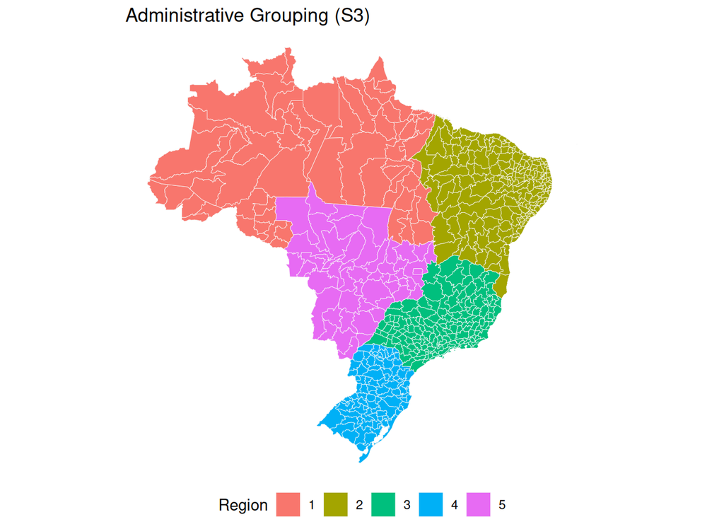

```r
# Attach per-area IDs to the map (assumes row order aligns with area index)
map_df$region_admin <- factor(id_regions_admin_area,
                              levels = sort(unique(id_regions_admin_area)))
map_df$region_biome <- factor(id_regions_biome_area,
                              levels = sort(unique(id_regions_biome_area)))

pal_admin <- hue_pal()(length(levels(map_df$region_admin)))
pal_biome <- hue_pal()(length(levels(map_df$region_biome)))

# Subtle borders for legibility
border_col <- "#f7f7f7"

p_admin <- ggplot(map_df) +
  geom_sf(aes(fill = region_admin), linewidth = 0.15, color = border_col) +
  scale_fill_manual(values = pal_admin, name = "Region") +
  ggtitle("Administrative Grouping (S3)") +
  theme_void() + theme(legend.position = "bottom")

p_biome <- ggplot(map_df) +
  geom_sf(aes(fill = region_biome), linewidth = 0.15, color = border_col) +
  scale_fill_manual(values = pal_biome, name = "Biome") +
  ggtitle("Terrestrial Biomes (S4)") +
  theme_void() + theme(legend.position = "bottom")

if (Six_terrestrial_biomes) p_biome else p_admin
```

**Interpretation.** If climatology or environmental gradients are important, the **biome partition** may better capture changes in spatial variability. If policy or health systems differ by region, the **administrative partition** can be more relevant.

## 7 7. Model Formulation

We model counts using a **Poisson** likelihood with an **offset** for expected counts:

$$Y_{i,t} \sim \text{Poisson}(E_{i,t}\, e^{\eta_{i,t}}), \quad
\eta_{i,t} = \mu + \alpha_i + \kappa_t.$$

- $\alpha_i$: spatial effect over microregions.
  - **Stationary Besag**: one global precision $\tau$.
  - **Flexible `fbesag`**: **region-specific** precisions $\tau_1,\ldots,\tau_P$ with **PC prior** that **contracts** to the stationary case (Abdul-Fattah et al. 2024).
- $\kappa_t$: **RW1** temporal trend.
- $\mu$: intercept.

We also **scale** the spatial structure (sum-to-zero constraint) for identifiability.

```r
# Scale the intrinsic graph for a sum-to-zero constraint
constr.inter <- list(A = matrix(1, 1, dim(graph)[1]), e = rep(0, 1))
scaled_graph <- as.matrix(INLA:::inla.scale.model(graph, constr.inter))

# PC prior for the stationary Besag precision
precision.prior <- list(prec = list(prior = "pc.prec", param = c(0.5, 0.01)))

# Flexible model object (region-specific precisions)
# sd_gamma controls the flexibility: smaller -> stronger contraction to stationarity
fbesag.model <- fbesag::get_fbesag(
  graph,
  id       = id_regions[1:558],
  sd_gamma = 0.15,
  param    = list(p1 = 1, p2 = 1e-5)
)
```

```
## [1] "/home/abdulfe/R/x86_64-pc-linux-gnu-library/4.5/fbesag"
```

```r
# Indices for INLA
data$c_S1 <- data$S1
data$c_T1 <- data$T1

# Expected counts for offset
E_counts <- if (E_is_log) exp(data$E) else data$E

# Stationary Besag (intrinsic via generic0)
baseformula <- Y ~ 1 +
  f(S1, model = "generic0",
    Cmatrix = scaled_graph,
    constr  = TRUE, rankdef = 1,
    hyper   = precision.prior) +
  f(T1, model = "rw1",
    constr = TRUE, scale.model = TRUE,
    hyper  = list(prec = list(prior = "pc.prec", param = c(0.5, 0.01))))

# Flexible Besag
formula <- Y ~ 1 +
  f(S1, model = fbesag.model, constr = TRUE, rankdef = 1) +
  f(T1, model = "rw1",
    constr = TRUE, scale.model = TRUE,
    hyper  = precision.prior)
```

**Notes.**  
- The `generic0` latent effect uses the **scaled** structure matrix.  
- `sd_gamma = 0.15` gives moderate flexibility; try `0.05` (tighter contraction) or `0.30` (more heterogeneity) in sensitivity checks.

## 8 8. Model Fitting with INLA

We use INLA’s **Gaussian** strategy with **empirical Bayes** integration for speed and stable results. Both models share the same likelihood, offset, and temporal component to enable **fair comparison**.

```r
config_flag <- FALSE

model_naive <- inla(
  formula = baseformula, data = data, family = "poisson", offset = log(E_counts),
  control.inla = list(strategy = "gaussian", int.strategy = "eb"),
  control.compute = list(dic = TRUE, config = config_flag,
                         cpo = TRUE, return.marginals = FALSE,
                         control.gcpo = list(enable = TRUE, num.level.sets = 2)),
  control.fixed = list(correlation.matrix = TRUE, prec.intercept = 1, prec = 1),
  control.predictor = list(link = 1, compute = TRUE),
  verbose = TRUE
)

model_fbesag <- inla(
  formula = formula, data = data, family = "poisson", offset = log(E_counts),
  control.inla = list(strategy = "gaussian", int.strategy = "eb"),
  control.compute = list(dic = TRUE, config = config_flag,
                         cpo = TRUE, return.marginals = FALSE,
                         control.gcpo = list(enable = TRUE, num.level.sets = 2)),
  control.fixed = list(correlation.matrix = TRUE, prec.intercept = 1, prec = 1),
  control.predictor = list(link = 1, compute = TRUE),
  verbose = TRUE
)
```

**Tip.** For final results, consider re-fitting with **full Laplace** or **central composite design** (`int.strategy`) if runtime allows.

## 9 9. Model Comparison

We summarize four complementary metrics:

- **DIC**: lower is better (penalized fit).
- **logML**: higher is better (marginal likelihood).
- **GCPO**: lower is better (geometric mean of leave-one-out predictive *p*-values).
- **MAE**: lower is better (median fitted vs observed).

```r
mean_neglog <- function(v) {
  v <- v[is.finite(v) & v > 0]
  if (length(v) == 0) return(NA_real_)
  -mean(log(v))
}

gcpo_naive  <- if (!is.null(model_naive$gcpo))  mean_neglog(model_naive$gcpo$gcpo) else mean_neglog(model_naive$cpo$cpo)
gcpo_fbesag <- if (!is.null(model_fbesag$gcpo)) mean_neglog(model_fbesag$gcpo$gcpo) else mean_neglog(model_fbesag$cpo$cpo)

mae_naive  <- hydroGOF::mae(model_naive$summary.fitted.values$`0.5quant`, data$Y, na.rm = TRUE)
mae_fbesag <- hydroGOF::mae(model_fbesag$summary.fitted.values$`0.5quant`, data$Y, na.rm = TRUE)

res <- tibble::tibble(
  Model = c("Stationary Besag", "Flexible Besag"),
  DIC   = c(round(model_naive$dic$dic, 0), round(model_fbesag$dic$dic, 0)),
  logML = c(as.numeric(model_naive$mlik[1]), as.numeric(model_fbesag$mlik[1])),
  GCPO  = c(gcpo_naive, gcpo_fbesag),
  MAE   = c(mae_naive, mae_fbesag)
)

res$`Better than stationary?` <- c(NA,
  (res$DIC[2]   < res$DIC[1]) &
  (res$logML[2] > res$logML[1]) &
  (res$GCPO[2]  < res$GCPO[1]) &
  (res$MAE[2]   < res$MAE[1])
)

knitr::kable(res, digits = 3, align = "lrrrrc",
             caption = "Lower DIC/GCPO/MAE and higher logML indicate improvement.")
```

Lower DIC/GCPO/MAE and higher logML indicate improvement.

| Model | DIC | logML | GCPO | MAE | Better than stationary? |
| --- | --- | --- | --- | --- | --- |
| Stationary Besag | -61840 | -118863.2 | 16.551 | 37.079 | NA |
| Flexible Besag | -61912 | -118609.0 | 16.550 | 37.078 | TRUE |

**How to read this table.** If the flexible model improves **most/all** metrics, there is evidence that **spatial heterogeneity** in precision matters. If results are similar, the **PC prior** likely contracted to the stationary model—`fbesag` then serves as a **diagnostic** of stationarity.

## 10 10. SMR by Microregion

The **Standardized Morbidity Ratio (SMR)** compares observed to expected counts (averaged over time for each microregion). It provides a **model-free** view of relative risk to contextualize what the spatial field is trying to capture.

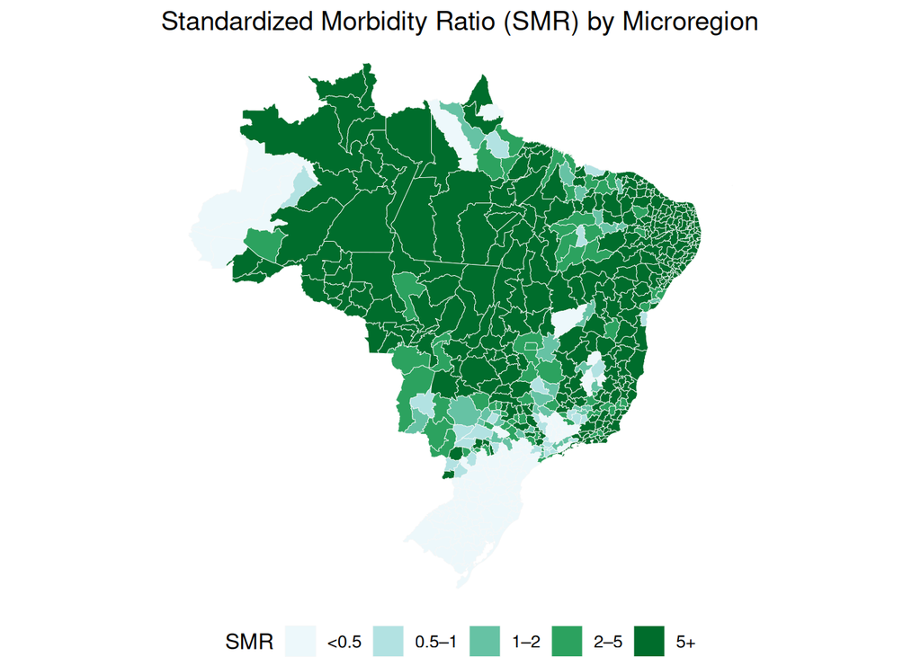

```r
# Average SMR per microregion
SMR <- vapply(1:558, function(i) {
  yy <- data$Y[data$S1 == i]
  ee <- E_counts[data$S1 == i]
  mean(yy / ee)
}, numeric(1))

map_df$SMR_cat <- cut(
  SMR, breaks = c(-Inf, 0.5, 1, 2, 5, Inf),
  labels = c("<0.5", "0.5–1", "1–2", "2–5", "5+"),
  right = FALSE, ordered_result = TRUE
)

pal_smr <- c("#edf8fb", "#b2e2e2", "#66c2a4", "#2ca25f", "#006d2c")
border_col <- "#f7f7f7"

ggplot(map_df) +
  geom_sf(aes(fill = SMR_cat), linewidth = 0.15, color = border_col) +
  scale_fill_manual(values = pal_smr, name = "SMR") +
  ggtitle("Standardized Morbidity Ratio (SMR) by Microregion") +
  theme_void(base_size = 12) +
  theme(legend.position = "bottom")
```

**Interpretation.** Areas with **SMR > 1** show higher-than-expected counts; however, SMR is **noisy in small populations**. Spatial models stabilize these estimates via **borrowing strength**.

## 11 11. Non‑stationarity Diagnostics (fbesag vs. stationary)

We inspect how the **posterior spatial effect** changes when allowing non-stationarity. We plot three **difference maps** (flexible − stationary): posterior **mean**, and the **2.5%** and **97.5%** quantiles.

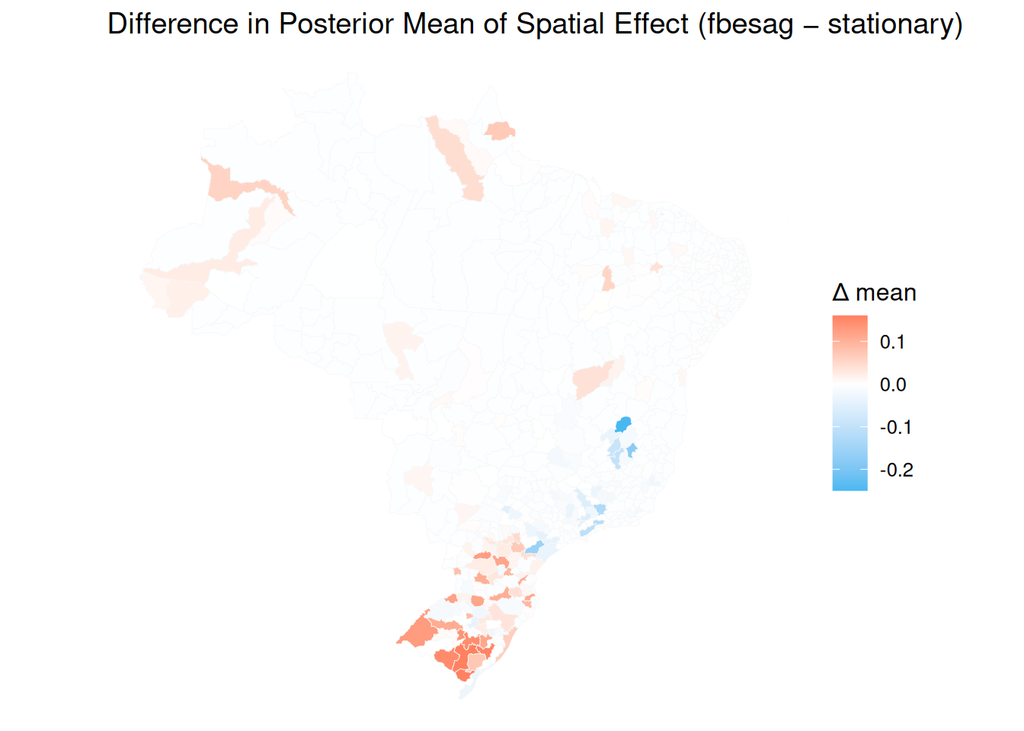

```r
# Differences in spatial field summaries
map_df$diff_mean <- model_fbesag$summary.random$S1$mean -
                    model_naive$summary.random$S1$mean

map_df$diff_q975 <- model_fbesag$summary.random$S1$`0.975quant` -
                    model_naive$summary.random$S1$`0.975quant`

map_df$diff_q025 <- model_fbesag$summary.random$S1$`0.025quant` -
                    model_naive$summary.random$S1$`0.025quant`

ga_blue <- "#49B8F1"
border_col <- "#f7f7f7"

p_mean <- ggplot(map_df) +
  geom_sf(aes(fill = diff_mean), linewidth = 0.15, color = border_col) +
  scale_fill_gradient2(low = ga_blue, mid = "white", high = "red", midpoint = 0, name = "\u0394 mean") +
  ggtitle("Difference in Posterior Mean of Spatial Effect (fbesag − stationary)") +
  theme_void(base_size = 12)

p_q975 <- ggplot(map_df) +
  geom_sf(aes(fill = diff_q975), linewidth = 0.15, color = border_col) +
  scale_fill_gradient2(low = ga_blue, mid = "white", high = "red", midpoint = 0, name = "\u0394 97.5%") +
  ggtitle("Difference in 97.5th Percentile of Spatial Effect") +
  theme_void(base_size = 12)

p_q025 <- ggplot(map_df) +
  geom_sf(aes(fill = diff_q025), linewidth = 0.15, color = border_col) +
  scale_fill_gradient2(low = ga_blue, mid = "white", high = "red", midpoint = 0, name = "\u0394 2.5%") +
  ggtitle("Difference in 2.5th Percentile of Spatial Effect") +
  theme_void(base_size = 12)

p_mean
```

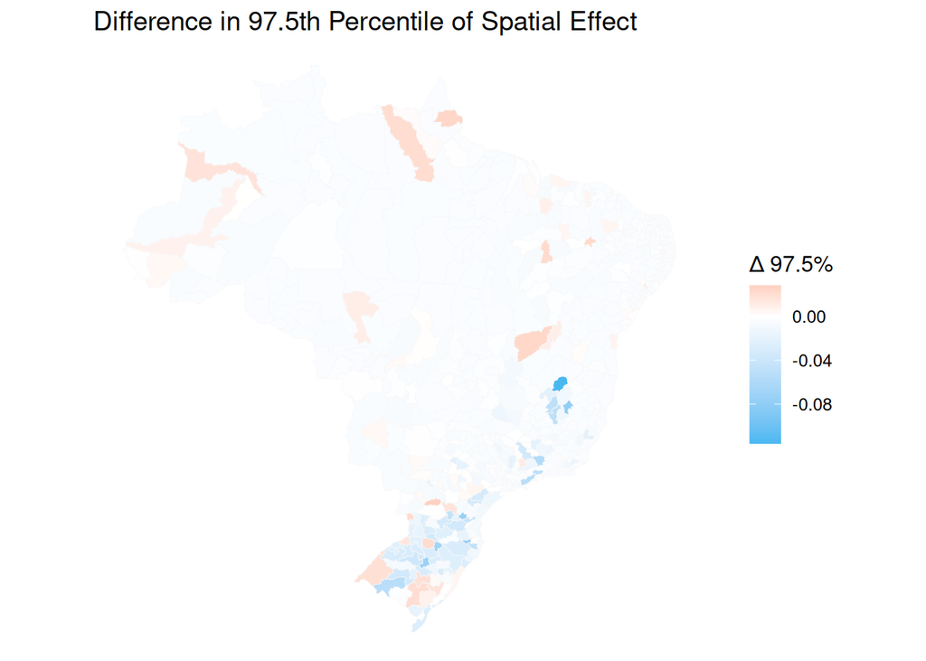

```r
p_q975
```

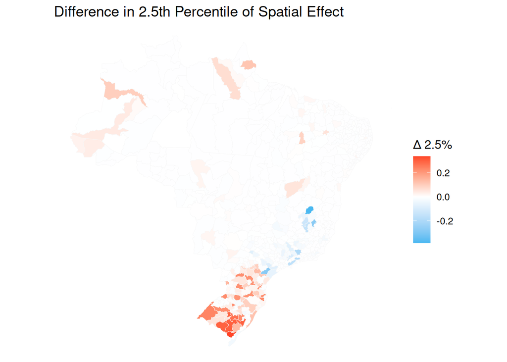

```r
p_q025
```

**Interpretation.**  
- Spatial zones where **mean differences** are large suggest regions where the **stationary assumption** is too restrictive.  
- If **credible interval lengths** shrink under `fbesag`, it may indicate **better local borrowing** thanks to region-specific precisions.

## 12 12. Regional Summary (Optional)

To summarize effects at the partition level, we compute the **average absolute change** in the posterior mean within each sub-region.

```r
ch <- id_regions[1:558]
abs_mean_diff_by_region <- vapply(sort(unique(ch)), function(k) {
  mean(abs(map_df$diff_mean[ch == k]))
}, numeric(1))

tibble::tibble(
  Region = sort(unique(ch)),
  `Mean |Δ mean|` = abs_mean_diff_by_region
) %>%
  knitr::kable(digits = 4, caption = "Average absolute change in posterior mean (by sub-region).")
```

Average absolute change in posterior mean (by sub-region).

| Region | Mean \|Δ mean\| |
| --- | --- |
| 1 | 0.0069 |
| 2 | 0.0046 |
| 3 | 0.0154 |
| 4 | 0.0389 |
| 5 | 0.0040 |

**Use.** Regions with larger values deserve closer inspection: they may be **drivers of non-stationarity** or reflect **true heterogeneity** in the underlying process.

## 14. References

Abdul-Fattah, Esmail, Elias Krainski, Janet van Niekerk, and Håvard Rue. 2024. “Non-Stationary Bayesian Spatial Model for Disease Mapping Based on Sub-Regions.” *Statistical Methods in Medical Research* 33 (6): 1093–1111. https://doi.org/10.1177/09622802241244613.